# Code pour le projet Fire

## Données

Création du jeu de données : 3 espèces (sp1, sp2 et sp3), 3 parcelles (p1, p2 et p3).

```r
ma_liste <- data.frame(Parcelle = c(rep("p1", 5), rep("p2", 4),  rep("p3", 3)),
                         Espece= c(rep("sp1", 3), "sp2", "sp3",
                                   "sp1", rep("sp2", 6)))
ma_liste
```

```
##    Parcelle Espece
## 1        p1    sp1
## 2        p1    sp1
## 3        p1    sp1
## 4        p1    sp2
## 5        p1    sp3
## 6        p2    sp1
## 7        p2    sp2
## 8        p2    sp2
## 9        p2    sp2
## 10       p3    sp2
## 11       p3    sp2
## 12       p3    sp2
```

## Table de contingence

Pour créer un tableau dont les lignes sont les parcelles et les colonnes les espèces, il faut d’abord regrouper les lignes et compter:

```r
library("tidyverse")
ma_liste %>%
  group_by(Parcelle, Espece) %>%
  summarize(Abondance = n())
```

```
## # A tibble: 6 × 3
## # Groups:   Parcelle [3]
##   Parcelle Espece Abondance
##   <chr>    <chr>      <int>
## 1 p1       sp1            3
## 2 p1       sp2            1
## 3 p1       sp3            1
## 4 p2       sp1            1
## 5 p2       sp2            3
## 6 p3       sp2            3
```

Ensuite, `pivot_wider()` permet d’élargir le tableau (la fonction `pivot_longer()` permet de faire le contraire, notamment pour préparer des données pour `ggplot()`). Le code complet est :

```r
library("tidyverse")
ma_liste %>%
  group_by(Parcelle, Espece) %>%
  # .groups ajouté pour faire disparaître l'avertissement
  summarize(Abondance = n(), .groups = 'drop') %>%
  pivot_wider(names_from = Espece, values_from = Abondance, values_fill = 0) ->
  # Tibble
  mon_tableau
mon_tableau
```

```
## # A tibble: 3 × 4
##   Parcelle   sp1   sp2   sp3
##   <chr>    <int> <int> <int>
## 1 p1           3     1     1
## 2 p2           1     3     0
## 3 p3           0     3     0
```

## Statistiques

La technique consiste à compter les cases du tableau qui respectent un critère (exemple : exactement un individu pour définir un singleton). On teste chaque case du tableau pour le transformer en valeurs vraies ou fausses:

```r
mon_tableau == 1
```

```
##      Parcelle   sp1   sp2   sp3
## [1,]    FALSE FALSE  TRUE  TRUE
## [2,]    FALSE  TRUE FALSE FALSE
## [3,]    FALSE FALSE FALSE FALSE
```

La colonne `Parcelle` pose problème parce qu’elle contient le nom de la parcelle et pas un nombre. La façon propre de régler le problème est de l’éliminer de tous les calculs:

```r
mon_tableau[, -1] == 1
```

```
##        sp1   sp2   sp3
## [1,] FALSE  TRUE  TRUE
## [2,]  TRUE FALSE FALSE
## [3,] FALSE FALSE FALSE
```

Tant que les tests sont numériques et que la colonne renvoie systématiquement `FALSE`, il est plus simple de l’ignorer.

On compte les cases en en faisant la somme (`TRUE` vaut 1, `FALSE` vaut 0):

```r
# Somme des singletons par ligne du tableau
rowSums(mon_tableau == 1)
```

```
## [1] 2 1 0
```

Le code complet est finalement :

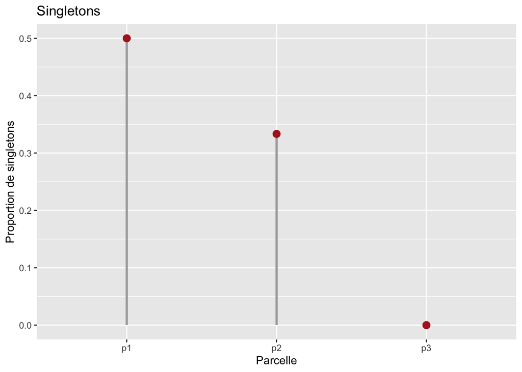

```r
# Nombre d'espèces
nb_especes <- rowSums(mon_tableau > 0)
# Nombre de singletons
nb_singletons <- rowSums(mon_tableau == 1)
# Proportion
prop_singletons <-  nb_singletons / nb_especes
# Figure : ajouter les valeurs calculées au tableau original
# Une colonne supplémentaire
cbind(mon_tableau, prop_singletons) %>%
  ggplot(aes(x = Parcelle, y = prop_singletons)) +
  geom_segment(aes(xend = Parcelle, yend = 0), size = 1, color = "darkgrey") +
    geom_point(size = 3, color = "firebrick") +
    labs(title = "Singletons",
         x = "Parcelle",
         y = "Proportion de singletons")
```

## Filtrage des espèces rares

Pour éliminer les espèces rares (ici, moins de 20% des effectifs d’une parcelle), il faut utiliser la même technique

```r
mon_tableau <= 0.2 * rowSums(mon_tableau[, -1])
```

```
##      Parcelle   sp1   sp2  sp3
## [1,]    FALSE FALSE  TRUE TRUE
## [2,]    FALSE FALSE FALSE TRUE
## [3,]    FALSE  TRUE FALSE TRUE
```

Remarquer que les valeurs du test

```r
 0.2 * rowSums(mon_tableau[, -1])
```

```
## [1] 1.0 0.8 0.6
```

sont recyclées par R : chaque valeur de la première ligne du tableau est comparée à 1, chaque valeur de la deuxième ligne à 0,8.

Il reste à remplacer le contenu des cellules `TRUE` par 0 par une opération de multiplication: `FALSE` vaut 0 donc multiplier par `FALSE` donne 0, alors que multiplier par `TRUE` ne change rien. On inverse le test pour que les cellules à modifier soient `FALSE`:

```r
mon_tableau[, -1] * (mon_tableau[, -1] > 0.2 * rowSums(mon_tableau[, -1]))
```

```
##   sp1 sp2 sp3
## 1   3   0   0
## 2   1   3   0
## 3   0   3   0
```

La colonne des noms ne peut pas être multipliée, donc il a fallu la retirer de l’opération. Pour recréer le tableau complet, il faut la rajouter à la fin. Le code complet est donc:

```r
mon_tableau_filtre <- cbind(mon_tableau[, 1],
                            mon_tableau[, -1] * (mon_tableau[, -1] > 0.2 * rowSums(mon_tableau[, -1])))
mon_tableau_filtre
```

```
##   Parcelle sp1 sp2 sp3
## 1       p1   3   0   0
## 2       p2   1   3   0
## 3       p3   0   3   0
```

## Tirages

Pour échantillonner les parcelles, on tire dans une loi multinomiale. Pour cela, il faut d’abord calculer les probabilités des espèces dans chaque parcelle :

```r
# Eliminer la première colonne de mon_tableau qui contient les noms
(mes_probabilites <- mon_tableau[, -1] / rowSums(mon_tableau[, -1]))
```

```
##    sp1  sp2 sp3
## 1 0.60 0.20 0.2
## 2 0.25 0.75 0.0
## 3 0.00 1.00 0.0
```

Ensuite, tirer dans la loi multinomiale avec `rmultinom()`. Le premier paramètre est le nombre de tirages.

La fonction `apply()` permet d’appliquer `rmultinom()` à chaque ligne (`MARGIN = 1`) du tableau des probabilités, qui est le vecteur des probabilités des espèces dans chaque parcelle. Comme le vecteur des probabilités n’est pas le premier argument de `rmultinom()`, il faut déclarer une fonction intermédiaire sans nom (appelée “fonction lambda”) pour passer les arguments correctement. Son argument unique est le contenu d’une ligne du tableau :

```r
taille_echantillon <- 300
apply(mes_probabilites, MARGIN = 1, FUN = function(proba_especes) rmultinom(1, size = taille_echantillon, prob = proba_especes))
```

```
##      [,1] [,2] [,3]
## [1,]  186   75    0
## [2,]   64  225  300
## [3,]   50    0    0
```

`apply()` arrange les vecteurs renvoyés par `rmultinom()` sous forme de colonnes d’une matrice. Pour respecter notre format d’origine, il faut la transposer.

Au final :

```r
taille_echantillon <- 300
mes_probabilites %>%
  apply(MARGIN = 1, FUN = function(proba_especes) rmultinom(1, size = taille_echantillon, prob = proba_especes)) %>%
  t() -> mes_echantillons
mes_echantillons
```

```
##      [,1] [,2] [,3]
## [1,]  176   57   67
## [2,]   72  228    0
## [3,]    0  300    0
```

## Espérance de la distance de Bray-Curtis

La distance de Bray-Curtis entre les parcelles est calculée avec **vegan**.

```r
library("vegan")
mes_dist <- vegdist(mon_tableau[, -1], method="bray")
mes_dist
```

```
##           1         2
## 2 0.5555556
## 3 0.7500000 0.1428571
```

L’objet obtenu est de classe `dist`. C’est une demi-matrice inférieure sans diagonale, difficile à manipuler, qui peut être transformé en matrice.

```r
as.matrix(mes_dist)
```

```
##           1         2         3
## 1 0.0000000 0.5555556 0.7500000
## 2 0.5555556 0.0000000 0.1428571
## 3 0.7500000 0.1428571 0.0000000
```

Pour stocker les distances entre parcelles simulées, le plus simple est de créer un tableau en 3 dimensions, de classe `array`: la troisième dimension permet d’empiler les matrices de distances simulées.

Les `array` se comportent comme des matrices. Par exemple, pour créer un tableau de 3 lignes, 3 colonnes et 2 couches:

```r
mon_array <- array(1:18, dim = c(3, 3, 2))
# Première couche
mon_array[, , 1]
```

```
##      [,1] [,2] [,3]
## [1,]    1    4    7
## [2,]    2    5    8
## [3,]    3    6    9
```

Pour nos simulations, on crée un tableau de la taille du nombre de parcelles en lignes et colonnes et avec autant de couches que de simulations. Le code complet est:

```r
# Nombre de simulations
nb_simulations <- 1000
# Taille des échantillons
taille_echantillon <- 300

# Nombre de parcelles
nb_parcelles <- ncol(mon_tableau)-1
# Tableau de stockage des résultats des simulations
mes_simulations <- array(0, dim=c(nb_parcelles, nb_parcelles, nb_simulations))
# Éliminer la première colonne de mon_tableau qui contient les noms
mes_probabilites <- mon_tableau[, -1] / rowSums(mon_tableau[, -1])
# Boucle de simulation
for(i in seq_len(nb_simulations)) {
  mes_probabilites %>%
    # Tirage des échantillons selon une loi multinomiale
    apply(MARGIN = 1, FUN = function(proba_especes) rmultinom(1, size = taille_echantillon, prob = proba_especes)) %>%
    # Transposition pour remettre les parcelles en lignes
    t() %>%
    # Calcul de la distance
    vegdist(method="bray") %>%
    # Transformation en matrice
    as.matrix() ->
    # Stockage dans une couche du tableau
    mes_simulations[, , i]
}
# Calcul des distances moyennes
(dist_bray_curtis <- apply(mes_simulations, MARGIN = c(1, 2) , mean))
```

```
##           [,1]      [,2]      [,3]
## [1,] 0.0000000 0.5502900 0.8003667
## [2,] 0.5502900 0.0000000 0.2500767
## [3,] 0.8003667 0.2500767 0.0000000
```

La distribution des distances simulées peut être affichée dans un graphique:

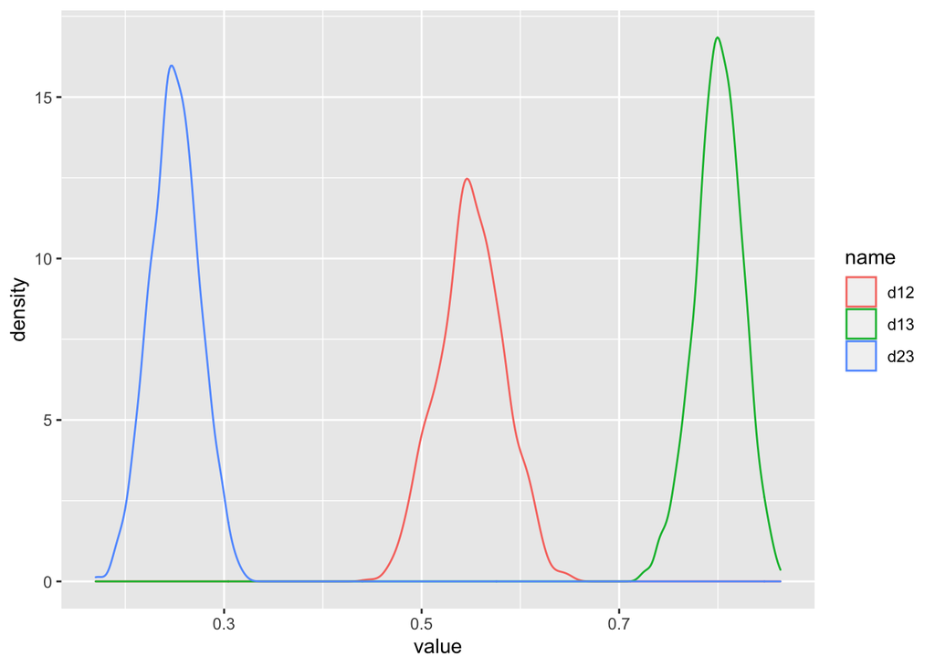

```r
# Distribution des distances moyennes
tibble(d12=mes_simulations[1, 2, ], d13=mes_simulations[1, 3, ], d23=mes_simulations[2, 3, ]) %>%
  # Données longues pour ggplot (cf. pivot_wider plus haut)
  pivot_longer(cols = everything()) %>%
  ggplot() +
    geom_density(aes(x=value, col=name))
```

## Diversité

Le package **entropart** permet de décomposer la diversité. Les données sont des dataframes avec les espèces en ligne, à transformer en objet `MetaCommunity`.

```r
# Transposition pour mettre les espèces en ligne
mes_communautes <- t(mon_tableau[, -1])
# Noms de colonnes = parcelles
colnames(mes_communautes) <- mon_tableau$Parcelle
mes_communautes
```

```
##     p1 p2 p3
## sp1  3  1  0
## sp2  1  3  3
## sp3  1  0  0
```

```r
library("entropart")
# Creation d'une metacommunaute = un assemblage de communautés
# Les poids sont les nombres d'individus (pour bénéficier de meilleurs estimateurs de la diversité)
ma_metacommunaute <- MetaCommunity(mes_communautes, Weights = colSums(mes_communautes))
# Les avertissements sont dus aux petits effectifs.
summary(ma_metacommunaute)
```

```
## Meta-community (class 'MetaCommunity') made of 12 individuals in 3
## communities and 3 species.
##
## Its sample coverage is 1
##
## Community weights are:
##        p1        p2        p3
## 0.4166667 0.3333333 0.2500000
## Community sample numbers of individuals are:
## p1 p2 p3
##  5  4  3
## Community sample coverages are:
##        p1        p2        p3
## 0.7333333 1.0000000 1.0000000
```

La décomposition de la diversité est faite par la fonction `DivProfile`.

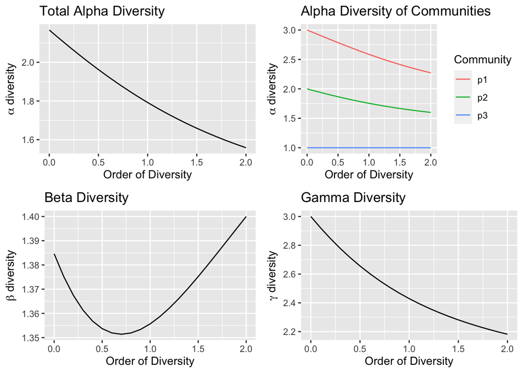

```r
DivProfile(, ma_metacommunaute) %>%  autoplot
```

Pour une décomposition hiérarchique, on peut créer une métacommunauté par montagne à partir des placettes de cette façon puis assembler les montagnes pour connaitre la diversité beta entre elles avec la fonction `MergeMC()`.

# Distances environnementales

Création des données : pour les trois parcelles p1 à p3, deux variables numériques v1 et v2.

```r
environnement <- data.frame(Parcelle = c("p1", "p2", "p3"),
                            v1= runif(3, min=0, max=1),
                            v2= runif(3, min=1000, max=5000))
environnement
```

```
##   Parcelle        v1       v2
## 1       p1 0.1549976 3952.949
## 2       p2 0.7823553 1633.328
## 3       p3 0.9951223 4162.884
```

L’objectif est d’obtenir un tableau dont les lignes sont les paires de parcelles, les colonnes les deux variables, et les valeurs la distance entre les deux parcelles de la paire:

```r
nb_parcelles
```

```
## [1] 3
```

```r
donnees_differences <- data.frame(d_Bray_Curtis=rep(0, nb_parcelles),
                                  v1=rep(0, nb_parcelles),
                                  v2=rep(0, nb_parcelles))
donnees_differences
```

```
##   d_Bray_Curtis v1 v2
## 1             0  0  0
## 2             0  0  0
## 3             0  0  0
```

Les distances de Bray-Curtis sont dans la matrice `dist_bray_curtis`. Pour remplir la colonne `d_Bray_Curtis`, il faut remettre les données sous la forme d’un vecteur. La méthode efficace est :

```r
dist_bray_curtis %>%
  # Conversion en objet dist pour éliminer les doublons
  as.dist %>%
  # Conversion en vecteur
  as.vector() ->
  donnees_differences$d_Bray_Curtis
donnees_differences
```

```
##   d_Bray_Curtis v1 v2
## 1     0.5502900  0  0
## 2     0.8003667  0  0
## 3     0.2500767  0  0
```

L’ordre des paires de parcelles est (p1, p2), (p1, p3), (p2, p3) : d’abord toutes les paires contenant la première parcelle.

Il reste à calculer les autres distances. `vegdist()` avec l’argument `method = "euclidian"` permet de produire directement les demi-matrices de distance : la distance euclidienne dans un espace à une dimension est la valeur absolue de la différence (imaginer une droite avec deux points). Pour la variable v1:

```r
environnement$v1 %>%
  vegdist(method = "euclidian") %>%
  as.vector()
```

```
## [1] 0.6273577 0.8401247 0.2127671
```

Pour traiter toutes les variables en une fois, on peut appliquer le traitement à toutes les colonnes:

```r
# Retirer la première colonne du tableau qui contient les noms des parcelles
d_v_envir <- apply(environnement[, -1],
      # Appliquer une fonction à chaque colonne
      MARGIN = 2,
      # La fonction calcule la distance euclidienne et la place dans un vecteur
      FUN = function(v_envir)
        as.vector(vegdist(v_envir, method = "euclidian")))
d_v_envir
```

```
##             v1        v2
## [1,] 0.6273577 2319.6215
## [2,] 0.8401247  209.9347
## [3,] 0.2127671 2529.5562
```

Le code complet pour mettre dans le même tableau la variable expliquée et les variables explicatives est finalement:

```r
# Création du dataframe avec la colonne de la variable expliquée
data.frame(d_Bray_Curtis=as.vector(as.dist(dist_bray_curtis))) %>%
  # Ajout des autres colonnes
  bind_cols(as.data.frame(d_v_envir)) -> donnees_differences
donnees_differences
```

```
##   d_Bray_Curtis        v1        v2
## 1     0.5502900 0.6273577 2319.6215
## 2     0.8003667 0.8401247  209.9347
## 3     0.2500767 0.2127671 2529.5562
```

Il reste à estimer le modèle:

```r
lm_distances <- lm(d_Bray_Curtis ~ v1 + v2, data = donnees_differences)
summary(lm_distances)
```

```
##
## Call:
## lm(formula = d_Bray_Curtis ~ v1 + v2, data = donnees_differences)
##
## Residuals:
## ALL 3 residuals are 0: no residual degrees of freedom!
##
## Coefficients:
##               Estimate Std. Error t value Pr(>|t|)
## (Intercept)  2.225e-01        NaN     NaN      NaN
## v1           6.998e-01        NaN     NaN      NaN
## v2          -4.796e-05        NaN     NaN      NaN
##
## Residual standard error: NaN on 0 degrees of freedom
## Multiple R-squared:      1,  Adjusted R-squared:    NaN
## F-statistic:   NaN on 2 and 0 DF,  p-value: NA
```

Avec 3 observations pour 2 variables, le modèle n’a aucun degré de liberté ici.